# Crop_Production_India

```python
import pandas as pd
import numpy as np
import matplotlib.pyplot as plt
import seaborn as sns
import warnings
warnings.filterwarnings('ignore')
```

## Load Dataset

```python
df=pd.read_csv("C:/Users/chetan devaliya/Downloads/archive (1)/crop_production.csv")
```

```python
df
```

|  | State_Name | District_Name | Crop_Year | Season | Crop | Area | Production |
| --- | --- | --- | --- | --- | --- | --- | --- |
| 0 | Andaman and Nicobar Islands | NICOBARS | 2000 | Kharif | Arecanut | 1254.0 | 2000.0 |
| 1 | Andaman and Nicobar Islands | NICOBARS | 2000 | Kharif | Other Kharif pulses | 2.0 | 1.0 |
| 2 | Andaman and Nicobar Islands | NICOBARS | 2000 | Kharif | Rice | 102.0 | 321.0 |
| 3 | Andaman and Nicobar Islands | NICOBARS | 2000 | Whole Year | Banana | 176.0 | 641.0 |
| 4 | Andaman and Nicobar Islands | NICOBARS | 2000 | Whole Year | Cashewnut | 720.0 | 165.0 |
| ... | ... | ... | ... | ... | ... | ... | ... |
| 246086 | West Bengal | PURULIA | 2014 | Summer | Rice | 306.0 | 801.0 |
| 246087 | West Bengal | PURULIA | 2014 | Summer | Sesamum | 627.0 | 463.0 |
| 246088 | West Bengal | PURULIA | 2014 | Whole Year | Sugarcane | 324.0 | 16250.0 |
| 246089 | West Bengal | PURULIA | 2014 | Winter | Rice | 279151.0 | 597899.0 |
| 246090 | West Bengal | PURULIA | 2014 | Winter | Sesamum | 175.0 | 88.0 |

246091 rows × 7 columns

## Top 5 Rows

```python
df.head()
```

|  | State_Name | District_Name | Crop_Year | Season | Crop | Area | Production |
| --- | --- | --- | --- | --- | --- | --- | --- |
| 0 | Andaman and Nicobar Islands | NICOBARS | 2000 | Kharif | Arecanut | 1254.0 | 2000.0 |
| 1 | Andaman and Nicobar Islands | NICOBARS | 2000 | Kharif | Other Kharif pulses | 2.0 | 1.0 |
| 2 | Andaman and Nicobar Islands | NICOBARS | 2000 | Kharif | Rice | 102.0 | 321.0 |
| 3 | Andaman and Nicobar Islands | NICOBARS | 2000 | Whole Year | Banana | 176.0 | 641.0 |
| 4 | Andaman and Nicobar Islands | NICOBARS | 2000 | Whole Year | Cashewnut | 720.0 | 165.0 |

## Last 5 Rows

```python
df.tail()
```

|  | State_Name | District_Name | Crop_Year | Season | Crop | Area | Production |
| --- | --- | --- | --- | --- | --- | --- | --- |
| 246086 | West Bengal | PURULIA | 2014 | Summer | Rice | 306.0 | 801.0 |
| 246087 | West Bengal | PURULIA | 2014 | Summer | Sesamum | 627.0 | 463.0 |
| 246088 | West Bengal | PURULIA | 2014 | Whole Year | Sugarcane | 324.0 | 16250.0 |
| 246089 | West Bengal | PURULIA | 2014 | Winter | Rice | 279151.0 | 597899.0 |
| 246090 | West Bengal | PURULIA | 2014 | Winter | Sesamum | 175.0 | 88.0 |

## Random 5 Rows

```python
df.sample(5)
```

|  | State_Name | District_Name | Crop_Year | Season | Crop | Area | Production |
| --- | --- | --- | --- | --- | --- | --- | --- |
| 162038 | Punjab | FIROZEPUR | 2001 | Rabi | Gram | 2000.0 | 1500.0 |
| 109441 | Madhya Pradesh | GUNA | 2003 | Kharif | Jowar | 42616.0 | 46111.0 |
| 60224 | Gujarat | JAMNAGAR | 2004 | Kharif | Arhar/Tur | 2300.0 | 2100.0 |
| 214621 | Uttar Pradesh | HATHRAS | 2010 | Kharif | Rice | 17158.0 | 30044.0 |
| 119141 | Madhya Pradesh | SAGAR | 2007 | Whole Year | Turmeric | 16.0 | 12.0 |

## Shape of Dataset

```python
df.shape
```

```
(246091, 7)
```

```python
print(f'The Given dataset contain Rows is : {246091}')
print(f'The Given dataset contain Columns is : {7}')
```

```
The Given dataset contain Rows is : 246091
The Given dataset contain Columns is : 7
```

## Total Size of Dataset

```python
df.size
```

```
1722637
```

```python
print(f'The given dataset size is : {1722637}')
```

```
The given dataset size is : 1722637
```

## Basic Information about Dataset

```python
df.info()
```

```
<class 'pandas.core.frame.DataFrame'>
RangeIndex: 246091 entries, 0 to 246090
Data columns (total 7 columns):
 #   Column         Non-Null Count   Dtype
---  ------         --------------   -----
 0   State_Name     246091 non-null  object
 1   District_Name  246091 non-null  object
 2   Crop_Year      246091 non-null  int64
 3   Season         246091 non-null  object
 4   Crop           246091 non-null  object
 5   Area           246091 non-null  float64
 6   Production     242361 non-null  float64
dtypes: float64(2), int64(1), object(4)
memory usage: 13.1+ MB
```

## Statical Information about Dataset

```python
df.describe()
```

|  | Crop_Year | Area | Production |
| --- | --- | --- | --- |
| count | 246091.000000 | 2.460910e+05 | 2.423610e+05 |
| mean | 2005.643018 | 1.200282e+04 | 5.825034e+05 |
| std | 4.952164 | 5.052340e+04 | 1.706581e+07 |
| min | 1997.000000 | 4.000000e-02 | 0.000000e+00 |
| 25% | 2002.000000 | 8.000000e+01 | 8.800000e+01 |
| 50% | 2006.000000 | 5.820000e+02 | 7.290000e+02 |
| 75% | 2010.000000 | 4.392000e+03 | 7.023000e+03 |
| max | 2015.000000 | 8.580100e+06 | 1.250800e+09 |

## Checking For Missing Value

```python
df.isnull().sum()
```

```
State_Name          0
District_Name       0
Crop_Year           0
Season              0
Crop                0
Area                0
Production       3730
dtype: int64
```

```python
3730/ 246091
```

```
0.015156994770227274
```

```python
#Dropping the sample having missing data
df.dropna(subset=['Production'], axis=0, inplace=True)
```

```python
df.describe()
```

|  | Crop_Year | Area | Production |
| --- | --- | --- | --- |
| count | 242361.000000 | 2.423610e+05 | 2.423610e+05 |
| mean | 2005.625773 | 1.216741e+04 | 5.825034e+05 |
| std | 4.958285 | 5.085744e+04 | 1.706581e+07 |
| min | 1997.000000 | 1.000000e-01 | 0.000000e+00 |
| 25% | 2002.000000 | 8.700000e+01 | 8.800000e+01 |
| 50% | 2006.000000 | 6.030000e+02 | 7.290000e+02 |
| 75% | 2010.000000 | 4.545000e+03 | 7.023000e+03 |
| max | 2015.000000 | 8.580100e+06 | 1.250800e+09 |

```python
df.shape
```

```
(242361, 7)
```

# Exploratory Analysis and Visualization

## Univariate Analysis

### State

```python
states = df.State_Name.str.strip().unique()
states
```

```
array(['Andaman and Nicobar Islands', 'Andhra Pradesh',
       'Arunachal Pradesh', 'Assam', 'Bihar', 'Chandigarh',
       'Chhattisgarh', 'Dadra and Nagar Haveli', 'Goa', 'Gujarat',
       'Haryana', 'Himachal Pradesh', 'Jammu and Kashmir', 'Jharkhand',
       'Karnataka', 'Kerala', 'Madhya Pradesh', 'Maharashtra', 'Manipur',
       'Meghalaya', 'Mizoram', 'Nagaland', 'Odisha', 'Puducherry',
       'Punjab', 'Rajasthan', 'Sikkim', 'Tamil Nadu', 'Telangana',
       'Tripura', 'Uttar Pradesh', 'Uttarakhand', 'West Bengal'],
      dtype=object)
```

```python
len(states)
```

```
33
```

```python
df.State_Name.value_counts()
```

```
State_Name
Uttar Pradesh                  33189
Madhya Pradesh                 22604
Karnataka                      21079
Bihar                          18874
Assam                          14622
Odisha                         13524
Tamil Nadu                     13266
Maharashtra                    12496
Rajasthan                      12066
Chhattisgarh                   10368
West Bengal                     9597
Andhra Pradesh                  9561
Gujarat                         8365
Telangana                       5591
Uttarakhand                     4825
Haryana                         4540
Kerala                          4003
Nagaland                        3904
Punjab                          3143
Meghalaya                       2867
Arunachal Pradesh               2545
Himachal Pradesh                2456
Jammu and Kashmir               1632
Tripura                         1412
Manipur                         1266
Jharkhand                       1266
Mizoram                          954
Puducherry                       872
Sikkim                           714
Dadra and Nagar Haveli           263
Goa                              207
Andaman and Nicobar Islands      201
Chandigarh                        89
Name: count, dtype: int64
```

- We have data from 33 states (including union territories). - We have more data from top agriculture rich states like Uttar Pradesh, MadhyaPradesh and Karnataka than other states.

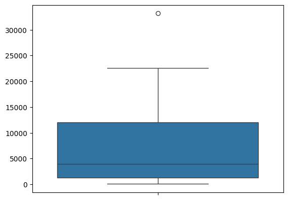

```python
sns.boxplot(df.State_Name.value_counts().values)
```

### District

```python
(len(df.District_Name.unique()),
 df.District_Name.unique())
```

```
(646,
 array(['NICOBARS', 'NORTH AND MIDDLE ANDAMAN', 'SOUTH ANDAMANS',
        'ANANTAPUR', 'CHITTOOR', 'EAST GODAVARI', 'GUNTUR', 'KADAPA',
        'KRISHNA', 'KURNOOL', 'PRAKASAM', 'SPSR NELLORE', 'SRIKAKULAM',
        'VISAKHAPATANAM', 'VIZIANAGARAM', 'WEST GODAVARI', 'ANJAW',
        'CHANGLANG', 'DIBANG VALLEY', 'EAST KAMENG', 'EAST SIANG',
        'KURUNG KUMEY', 'LOHIT', 'LONGDING', 'LOWER DIBANG VALLEY',
        'LOWER SUBANSIRI', 'NAMSAI', 'PAPUM PARE', 'TAWANG', 'TIRAP',
        'UPPER SIANG', 'UPPER SUBANSIRI', 'WEST KAMENG', 'WEST SIANG',
        'BAKSA', 'BARPETA', 'BONGAIGAON', 'CACHAR', 'CHIRANG', 'DARRANG',
        'DHEMAJI', 'DHUBRI', 'DIBRUGARH', 'DIMA HASAO', 'GOALPARA',
        'GOLAGHAT', 'HAILAKANDI', 'JORHAT', 'KAMRUP', 'KAMRUP METRO',
        'KARBI ANGLONG', 'KARIMGANJ', 'KOKRAJHAR', 'LAKHIMPUR', 'MARIGAON',
        'NAGAON', 'NALBARI', 'SIVASAGAR', 'SONITPUR', 'TINSUKIA',
        'UDALGURI', 'ARARIA', 'ARWAL', 'AURANGABAD', 'BANKA', 'BEGUSARAI',
        'BHAGALPUR', 'BHOJPUR', 'BUXAR', 'DARBHANGA', 'GAYA', 'GOPALGANJ',
        'JAMUI', 'JEHANABAD', 'KAIMUR (BHABUA)', 'KATIHAR', 'KHAGARIA',
        'KISHANGANJ', 'LAKHISARAI', 'MADHEPURA', 'MADHUBANI', 'MUNGER',
        'MUZAFFARPUR', 'NALANDA', 'NAWADA', 'PASHCHIM CHAMPARAN', 'PATNA',
        'PURBI CHAMPARAN', 'PURNIA', 'ROHTAS', 'SAHARSA', 'SAMASTIPUR',
        'SARAN', 'SHEIKHPURA', 'SHEOHAR', 'SITAMARHI', 'SIWAN', 'SUPAUL',
        'VAISHALI', 'CHANDIGARH', 'BALOD', 'BALODA BAZAR', 'BALRAMPUR',
        'BASTAR', 'BEMETARA', 'BIJAPUR', 'BILASPUR', 'DANTEWADA',
        'DHAMTARI', 'DURG', 'GARIYABAND', 'JANJGIR-CHAMPA', 'JASHPUR',
        'KABIRDHAM', 'KANKER', 'KONDAGAON', 'KORBA', 'KOREA', 'MAHASAMUND',
        'MUNGELI', 'NARAYANPUR', 'RAIGARH', 'RAIPUR', 'RAJNANDGAON',
        'SUKMA', 'SURAJPUR', 'SURGUJA', 'DADRA AND NAGAR HAVELI',
        'NORTH GOA', 'SOUTH GOA', 'AHMADABAD', 'AMRELI', 'ANAND',
        'BANAS KANTHA', 'BHARUCH', 'BHAVNAGAR', 'DANG', 'DOHAD',
        'GANDHINAGAR', 'JAMNAGAR', 'JUNAGADH', 'KACHCHH', 'KHEDA',
        'MAHESANA', 'NARMADA', 'NAVSARI', 'PANCH MAHALS', 'PATAN',
        'PORBANDAR', 'RAJKOT', 'SABAR KANTHA', 'SURAT', 'SURENDRANAGAR',
        'TAPI', 'VADODARA', 'VALSAD', 'AMBALA', 'BHIWANI', 'FARIDABAD',
        'FATEHABAD', 'GURGAON', 'HISAR', 'JHAJJAR', 'JIND', 'KAITHAL',
        'KARNAL', 'KURUKSHETRA', 'MAHENDRAGARH', 'MEWAT', 'PALWAL',
        'PANCHKULA', 'PANIPAT', 'REWARI', 'ROHTAK', 'SIRSA', 'SONIPAT',
        'YAMUNANAGAR', 'CHAMBA', 'HAMIRPUR', 'KANGRA', 'KINNAUR', 'KULLU',
        'LAHUL AND SPITI', 'MANDI', 'SHIMLA', 'SIRMAUR', 'SOLAN', 'UNA',
        'ANANTNAG', 'BADGAM', 'BANDIPORA', 'BARAMULLA', 'DODA',
        'GANDERBAL', 'JAMMU', 'KARGIL', 'KATHUA', 'KISHTWAR', 'KULGAM',
```

[output cut: 74 more lines]

```
        'JHANSI', 'KANNAUJ', 'KANPUR DEHAT', 'KANPUR NAGAR', 'KASGANJ',
        'KAUSHAMBI', 'KHERI', 'KUSHI NAGAR', 'LALITPUR', 'LUCKNOW',
        'MAHARAJGANJ', 'MAHOBA', 'MAINPURI', 'MATHURA', 'MAU', 'MEERUT',
        'MIRZAPUR', 'MORADABAD', 'MUZAFFARNAGAR', 'PILIBHIT', 'RAE BARELI',
        'RAMPUR', 'SAHARANPUR', 'SAMBHAL', 'SANT KABEER NAGAR',
        'SANT RAVIDAS NAGAR', 'SHAHJAHANPUR', 'SHAMLI', 'SHRAVASTI',
        'SIDDHARTH NAGAR', 'SITAPUR', 'SONBHADRA', 'SULTANPUR', 'UNNAO',
        'VARANASI', 'ALMORA', 'BAGESHWAR', 'CHAMOLI', 'CHAMPAWAT',
        'DEHRADUN', 'HARIDWAR', 'NAINITAL', 'PAURI GARHWAL', 'PITHORAGARH',
        'RUDRA PRAYAG', 'TEHRI GARHWAL', 'UDAM SINGH NAGAR', 'UTTAR KASHI',
        '24 PARAGANAS NORTH', '24 PARAGANAS SOUTH', 'BANKURA', 'BARDHAMAN',
        'BIRBHUM', 'COOCHBEHAR', 'DARJEELING', 'DINAJPUR DAKSHIN',
        'DINAJPUR UTTAR', 'HOOGHLY', 'HOWRAH', 'JALPAIGURI', 'MALDAH',
        'MEDINIPUR EAST', 'MEDINIPUR WEST', 'MURSHIDABAD', 'NADIA',
        'PURULIA'], dtype=object))
```

```python
df.District_Name.value_counts()
```

```
District_Name
TUMKUR       931
BELGAUM      924
BIJAPUR      905
HASSAN       895
BELLARY      887
            ...
HYDERABAD      8
RAMGARH        6
KHUNTI         6
MUMBAI         1
NAMSAI         1
Name: count, Length: 646, dtype: int64
```

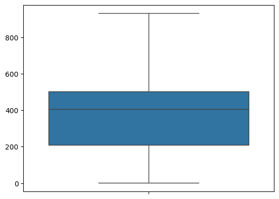

```python
sns.boxplot(df.District_Name.value_counts().values)
```

### Crop Year

```python
print(df.Crop_Year.nunique())
```

```
19
```

```python
print(df.Crop_Year.min())
```

```
1997
```

```python
print(df.Crop_Year.max())
```

```
2015
```

```python
df.Crop_Year.unique()
```

```
array([2000, 2001, 2002, 2003, 2004, 2005, 2006, 2010, 1997, 1998, 1999,
       2007, 2008, 2009, 2011, 2012, 2013, 2014, 2015])
```

```python
df.Crop_Year.value_counts()
```

```
Crop_Year
2003    17139
2002    16536
2007    14269
2008    14230
2006    13976
2004    13858
2010    13793
2011    13791
2009    13767
2000    13553
2005    13519
2013    13475
2001    13293
2012    13184
1999    12441
1998    11262
2014    10815
1997     8899
2015      561
Name: count, dtype: int64
```

- We have data of 19 years from 1997 to 2015. - The years having more data are - 2003, 2002, 2007, 2008 and 2006.

### Season

```python
print(df.Season.nunique())
df.Season = df.Season.str.strip()
```

```
6
```

```python
Seasons = df.Season.unique()
Seasons
```

```
array(['Kharif', 'Whole Year', 'Autumn', 'Rabi', 'Summer', 'Winter'],
      dtype=object)
```

```python
df.Season.max()
```

```
'Winter'
```

```python
df.Season.value_counts()
```

```
Season
Kharif        94283
Rabi          66160
Whole Year    56127
Summer        14811
Winter         6050
Autumn         4930
Name: count, dtype: int64
```

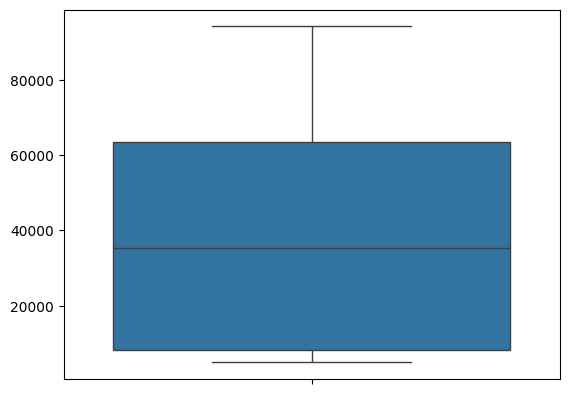

```python
sns.boxplot(df.Season.value_counts().values)
```

### Crop

```python
print(df.Crop.nunique())
```

```
124
```

```python
Crop = df.Crop.unique()
Crop
```

```
array(['Arecanut', 'Other Kharif pulses', 'Rice', 'Banana', 'Cashewnut',
       'Coconut ', 'Dry ginger', 'Sugarcane', 'Sweet potato', 'Tapioca',
       'Black pepper', 'Dry chillies', 'other oilseeds', 'Turmeric',
       'Maize', 'Moong(Green Gram)', 'Urad', 'Arhar/Tur', 'Groundnut',
       'Sunflower', 'Bajra', 'Castor seed', 'Cotton(lint)', 'Horse-gram',
       'Jowar', 'Korra', 'Ragi', 'Tobacco', 'Gram', 'Wheat', 'Masoor',
       'Sesamum', 'Linseed', 'Safflower', 'Onion', 'other misc. pulses',
       'Samai', 'Small millets', 'Coriander', 'Potato',
       'Other  Rabi pulses', 'Soyabean', 'Beans & Mutter(Vegetable)',
       'Bhindi', 'Brinjal', 'Citrus Fruit', 'Cucumber', 'Grapes', 'Mango',
       'Orange', 'other fibres', 'Other Fresh Fruits', 'Other Vegetables',
       'Papaya', 'Pome Fruit', 'Tomato', 'Mesta', 'Cowpea(Lobia)',
       'Lemon', 'Pome Granet', 'Sapota', 'Cabbage', 'Rapeseed &Mustard',
       'Peas  (vegetable)', 'Niger seed', 'Bottle Gourd', 'Varagu',
       'Garlic', 'Ginger', 'Oilseeds total', 'Pulses total', 'Jute',
       'Peas & beans (Pulses)', 'Blackgram', 'Paddy', 'Pineapple',
       'Barley', 'Sannhamp', 'Khesari', 'Guar seed', 'Moth',
       'Other Cereals & Millets', 'Cond-spcs other', 'Turnip', 'Carrot',
       'Redish', 'Arcanut (Processed)', 'Atcanut (Raw)',
       'Cashewnut Processed', 'Cashewnut Raw', 'Cardamom', 'Rubber',
       'Bitter Gourd', 'Drum Stick', 'Jack Fruit', 'Snak Guard', 'Tea',
       'Coffee', 'Cauliflower', 'Other Citrus Fruit', 'Water Melon',
       'Total foodgrain', 'Kapas', 'Colocosia', 'Lentil', 'Bean',
       'Jobster', 'Perilla', 'Rajmash Kholar', 'Ricebean (nagadal)',
       'Ash Gourd', 'Beet Root', 'Lab-Lab', 'Ribed Guard', 'Yam',
       'Pump Kin', 'Apple', 'Peach', 'Pear', 'Plums', 'Litchi', 'Ber',
       'Other Dry Fruit', 'Jute & mesta'], dtype=object)
```

```python
df.Crop.value_counts().head(25)
```

```
Crop
Rice                     15082
Maize                    13787
Moong(Green Gram)        10106
Urad                      9710
Sesamum                   8821
Groundnut                 8770
Wheat                     7878
Sugarcane                 7827
Rapeseed &Mustard         7533
Arhar/Tur                 7476
Gram                      7227
Jowar                     6990
Onion                     6984
Potato                    6914
Dry chillies              6421
Sunflower                 5483
Bajra                     5379
Small millets             4593
Peas & beans (Pulses)     4447
Cotton(lint)              4382
Linseed                   4351
Turmeric                  4168
Masoor                    4152
Sweet potato              4122
Ragi                      4116
Name: count, dtype: int64
```

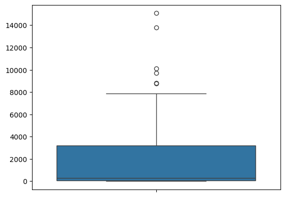

```python
sns.boxplot(df.Crop.value_counts().values)
```

### Area

```python
print(df.Area.max())
print(df.Area.min())
```

```
8580100.0
0.1
```

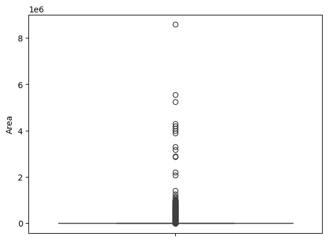

```python
sns.boxplot(df.Area)
```

### Production

```python
df.Production.describe()
```

```
count    2.423610e+05
mean     5.825034e+05
std      1.706581e+07
min      0.000000e+00
25%      8.800000e+01
50%      7.290000e+02
75%      7.023000e+03
max      1.250800e+09
Name: Production, dtype: float64
```

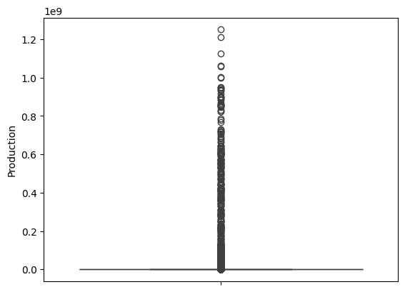

```python
sns.boxplot(df.Production)
```

## Create two columns Total Production and Productivity.

## Total Production

```python
df['Total Production'] = df['Production'] * df['Area']
```

```python
df["Total Production"]
```

```
0         2.508000e+06
1         2.000000e+00
2         3.274200e+04
3         1.128160e+05
4         1.188000e+05
              ...
246086    2.451060e+05
246087    2.903010e+05
246088    5.265000e+06
246089    1.669041e+11
246090    1.540000e+04
Name: Total Production, Length: 242361, dtype: float64
```

## Remove Outliers

```python
Q1= df["Total Production"].quantile(0.40)
Q3 =df["Total Production"].quantile (0.60)
IQR = Q3 - Q1
df =df[(df["Total Production"] >= Q1-1.5*IQR) & (df ["Total Production"]<=Q3+1.5*IQR)]
```

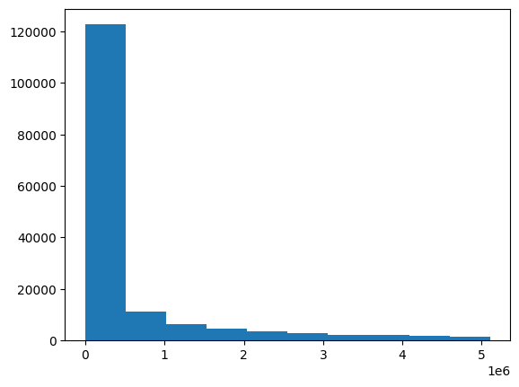

```python
plt.hist(df["Total Production"])
```

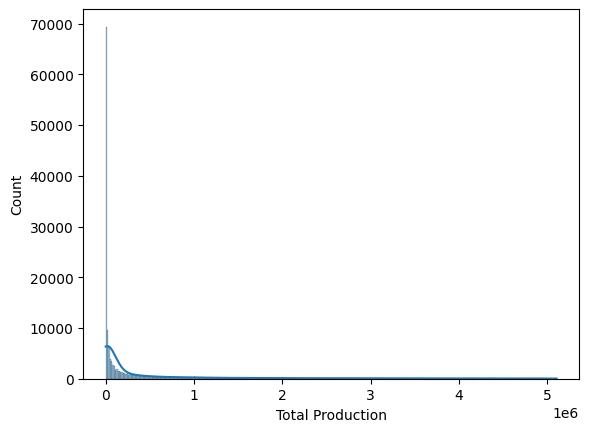

```python
sns.histplot(df['Total Production'], kde = True)
```

## Productivity

```python
df["Productivity"]=df["Production"]/df["Area"]
```

```python
df["Productivity"]
```

```
0         1.594896
1         0.500000
2         3.147059
3         3.642045
4         0.229167
            ...
246083    0.513636
246085    6.273846
246086    2.617647
246087    0.738437
246090    0.502857
Name: Productivity, Length: 158622, dtype: float64
```

```python
Q1 =df ["Productivity"].quantile (0.40)
Q3 =df["Productivity"].quantile (0.60)
IQR= Q3-Q1
df=df[(df["Productivity"] >= Q1 -1.5*IQR) & (df ["Productivity"] <= Q3+1.5*IQR)]
```

```python
df["Productivity"]
```

```
1         0.500000
4         0.229167
11        0.500000
13        0.267038
16        1.000000
            ...
246081    0.800000
246082    0.685185
246083    0.513636
246087    0.738437
246090    0.502857
Name: Productivity, Length: 103594, dtype: float64
```

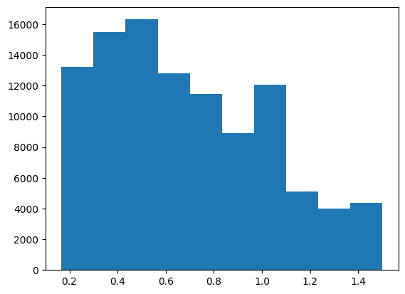

```python
plt.hist(df["Productivity"])
plt.show()
```

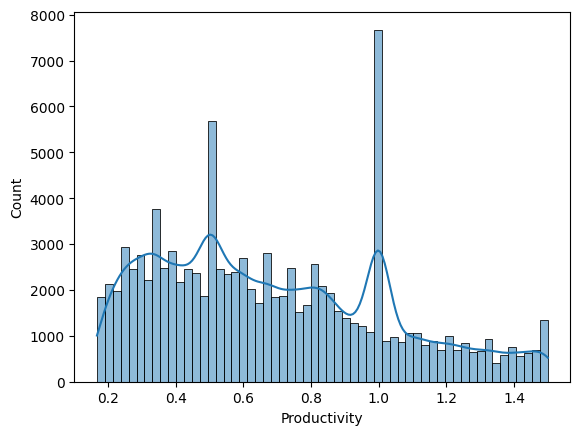

```python
sns.histplot(df['Productivity'], kde = True)
```

## Area

```python
df.Area
```

```
1            2.0
4          720.0
11           2.0
13         719.0
16           1.0
           ...
246081    1885.0
246082      54.0
246083     220.0
246087     627.0
246090     175.0
Name: Area, Length: 103594, dtype: float64
```

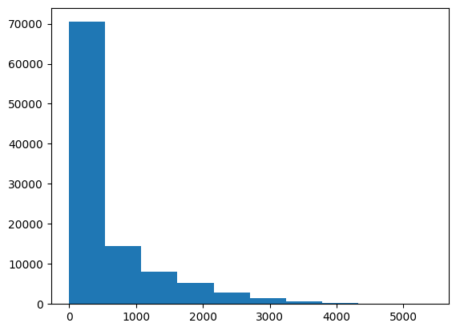

```python
plt.hist(df["Area"])
```

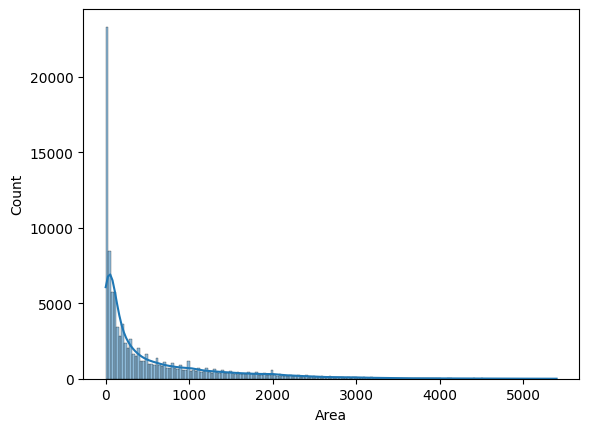

```python
sns.histplot(df['Area'], kde = True)
```

## Production

```python
df.Production
```

```
1            1.0
4          165.0
11           1.0
13         192.0
16           1.0
           ...
246081    1508.0
246082      37.0
246083     113.0
246087     463.0
246090      88.0
Name: Production, Length: 103594, dtype: float64
```

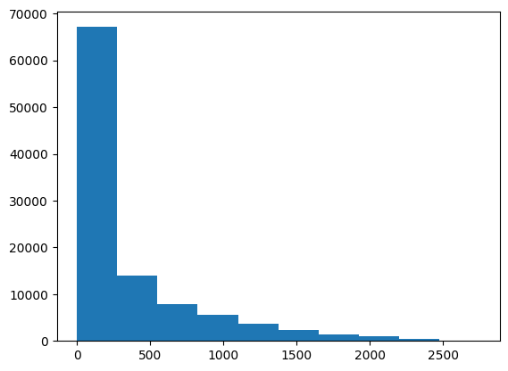

```python
plt.hist(df["Production"])
```

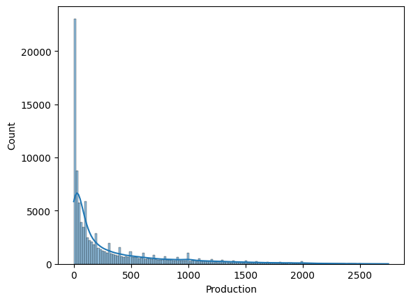

```python
sns.histplot(df['Production'], kde=True)
```

## Plot Crop Production over the Years.

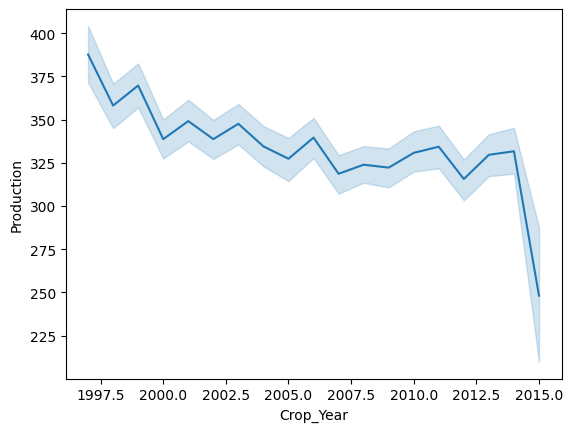

```python
sns.lineplot(x='Crop_Year', y='Production', data = df)
plt.show()
```

## Plot Crop Production By Crop

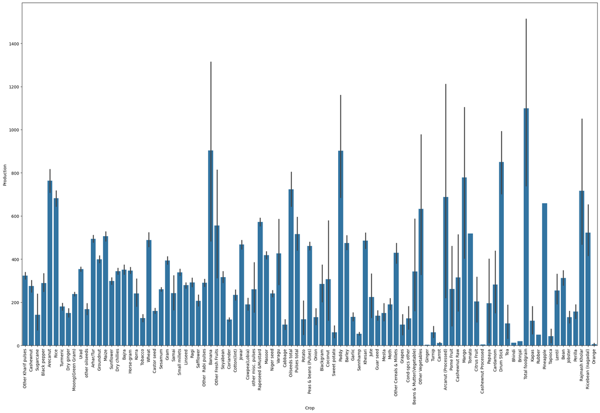

```python
plt.figure(figsize=(25,15))
sns.barplot(x='Crop', y='Production', data = df)
plt.xticks(rotation = 90)
plt.show()
```

## Plot Crop Production By State

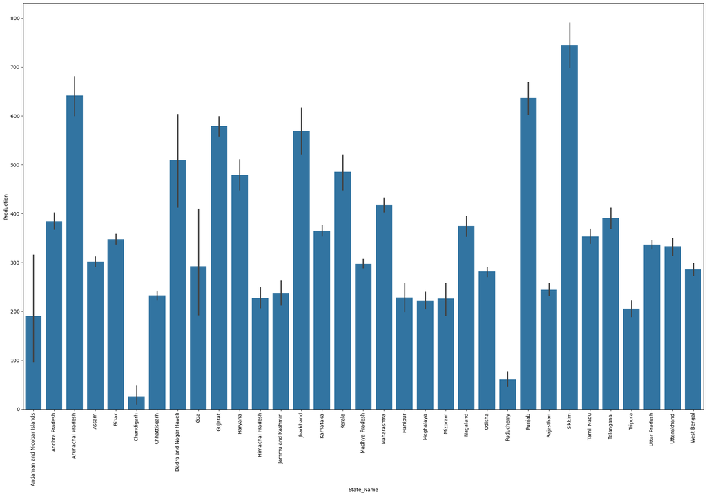

```python
plt.figure(figsize=(25,15))
sns.barplot(x='State_Name', y='Production', data = df)
plt.xticks(rotation = 90)
plt.show()
```

## Plot Crop Production by Season

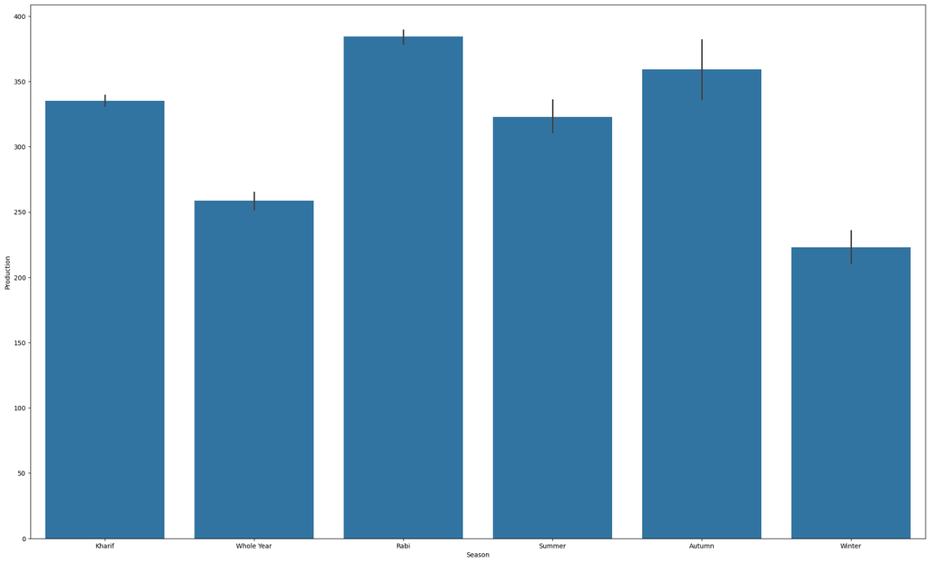

```python
plt.figure(figsize=(25,15))
sns.barplot(x='Season', y='Production', data = df)
plt.show()
```

```python
crop=df["Crop"]
```

```python
crop
```

```
1         Other Kharif pulses
4                   Cashewnut
11        Other Kharif pulses
13                  Cashewnut
16                  Sugarcane
                 ...
246081      Rapeseed &Mustard
246082              Safflower
246083                   Urad
246087                Sesamum
246090                Sesamum
Name: Crop, Length: 103594, dtype: object
```

```python
def crop_category(crop):
    for i in ['Rice','Maize','Wheat','Barley','Varagu','Other Cereals & Millets','Ragi','Small millets','Bajra','Jowar']:
        if crop==i:
            return 'Cereal'
    for i in ['Moong','Urad','Arhar/Tur','Peas & beans','Masoor',
              'Other Kharif pulses','other misc. pulses','Ricebean (nagadal)',
              'Rajmash Kholar','Lentil','Samai','Blackgram','Korra','Cowpea(Lobia)',
              'Other  Rabi pulses','Other Kharif pulses','Peas & beans (Pulses)']:
        if crop==i:
            return 'Pulses'
    for i in ['Peach','Apple','Litchi','Pear','Plums','Ber','Sapota','Lemon','Pome Granet',
               'Other Citrus Fruit','Water Melon','Jack Fruit','Grapes','Pineapple','Orange',
               'Pome Fruit','Citrus Fruit','Other Fresh Fruits','Mango','Papaya','Coconut','Banana']:
        if crop==i:
            return 'Fruits'
    for i in ['Bean','Lab-Lab','Moth','Guar seed','Tapioca','Soyabean','Horse-gram','Gram']:
        if crop==i:
            return 'Beans'
    for i in ['Turnip','Peas','Beet Root','Carrot','Yam','Ribed Guard','Ash Gourd ','Pump Kin','Redish','Snak Guard','Bottle Gourd',
              'Bitter Gourd','Cucumber','Drum Stick','Cauliflower','Beans & Mutter(Vegetable)','Cabbage',
              'Bhindi','Tomato','Brinjal','Khesari','Sweet potato','Potato','Onion']:
        if crop==i:
            return 'Vegetables'
    for i in ['Perilla','Colocosia','Ginger','Cardamom','Black pepper','Dry ginger','Garlic','Coriander','Turmeric','Dry chillies']:
        if crop==i:
            return 'Species'
    for i in ['Jobster','Cond-spcs other']:
        if crop==i:
            return 'Other'
    for i in ['other fibres','Kapas','Jute & mesta','Jute','Mesta','Cotton(lint)']:
        if crop==i:
            return 'fibres'
    for i in ['Arcanut (Processed)','Atcanut (Raw)','Cashewnut Processed','Cashewnut Raw','Cashewnut','Arecanut','Groundnut']:
        if crop==i:
            return 'Nuts'
    for i in ['Rubber']:
        if crop==i:
            return 'Natural Polymer'
    for i in ['Coffee']:
        if crop== i:
            return 'Coffee'
    for i in ['Tea']:
        if crop==i:
            return 'Tea'
    for i in ['Total foodgrain']:
        if crop==i:
            return 'Total foodgrain'
    for i in ['Pulses total']:
        if crop==i:
            return 'Pulses total'
    for i in ['Oilseeds total']:
        if crop==i:
            return 'Oilseeds total'
    for i in ['Paddy']:
        if crop==i:
            return 'Paddy'
    for i in ['other oilseeds','Safflower','Niger seed','Castor seed','Linseed','Sunflower','Rapeseed &Mustard','Sesamum']:
        if crop==i:
            return 'Oilseeds'
    for i in ['Sannhamp']:
        if crop==i:
            return 'Fertile Plant'
    for i in ['Tobacco']:
        if crop==i:
            return 'Commercial'
    for i in ['Sugarcane']:
        if crop==i:
            return 'Sugarcane'
df['crop_category']=df['Crop'].apply(crop_category)
```

```python
df['crop_category'].value_counts()
```

```
crop_category
Oilseeds           22668
Pulses             22614
Cereal             18275
Species            10719
Beans               9630
Nuts                5773
fibres              1588
Fertile Plant       1557
Commercial          1385
Vegetables          1327
Oilseeds total       228
Pulses total         138
Fruits               135
Sugarcane             69
Paddy                 28
Other                 27
Tea                   11
Total foodgrain        8
Natural Polymer        1
Name: count, dtype: int64
```

- A new variable 'Crop_category' is created. - Oilseeds,pulses and Cereals are top producing categories.

### NEW VARIABLE - PRODUCTION PER UNIT AREA

```python
df['Production_per_unit_area'] = df['Production'] / df['Area']
```

```python
df.Production_per_unit_area
```

```
1         0.500000
4         0.229167
11        0.500000
13        0.267038
16        1.000000
            ...
246081    0.800000
246082    0.685185
246083    0.513636
246087    0.738437
246090    0.502857
Name: Production_per_unit_area, Length: 103594, dtype: float64
```

# Visualising Data

## 1. State wise Production

```python
prod=df.groupby(by=df.State_Name)["Production"].sum().reset_index()
prod
```

|  | State_Name | Production |
| --- | --- | --- |
| 0 | Andaman and Nicobar Islands | 11773.57 |
| 1 | Andhra Pradesh | 1158330.00 |
| 2 | Arunachal Pradesh | 586564.98 |
| 3 | Assam | 2186176.00 |
| 4 | Bihar | 3568495.00 |
| 5 | Chandigarh | 531.50 |
| 6 | Chhattisgarh | 1465129.00 |
| 7 | Dadra and Nagar Haveli | 84546.00 |
| 8 | Goa | 17849.58 |
| 9 | Gujarat | 1640110.00 |
| 10 | Haryana | 501970.00 |
| 11 | Himachal Pradesh | 332248.00 |
| 12 | Jammu and Kashmir | 225993.70 |
| 13 | Jharkhand | 295055.61 |
| 14 | Karnataka | 2644771.52 |
| 15 | Kerala | 351278.96 |
| 16 | Madhya Pradesh | 2679518.00 |
| 17 | Maharashtra | 1977619.80 |
| 18 | Manipur | 95101.00 |
| 19 | Meghalaya | 289915.00 |
| 20 | Mizoram | 121551.23 |
| 21 | Nagaland | 905509.00 |
| 22 | Odisha | 2004469.20 |
| 23 | Puducherry | 21035.00 |
| 24 | Punjab | 846376.00 |
| 25 | Rajasthan | 1148944.00 |
| 26 | Sikkim | 388342.00 |
| 27 | Tamil Nadu | 1520019.64 |
| 28 | Telangana | 749236.00 |
| 29 | Tripura | 203385.00 |
| 30 | Uttar Pradesh | 4665575.00 |
| 31 | Uttarakhand | 917652.00 |
| 32 | West Bengal | 1293103.70 |

[figure not shown]

```python
plt.figure(figsize=(10,10))
x = prod['Production'].head(10).sort_values(ascending=True)
y = prod['State_Name'].head(10)
plt.barh( y,x)
plt.title('State wise production', fontsize= 30 , color = 'r')
plt.xlabel('Production', fontsize = 30 , color = 'g')
plt.ylabel('State_Name', fontsize = 30, color = 'g')
plt.show()
```

```python
df.Production.describe()
```

```
count    103594.000000
mean        336.874481
std         466.870533
min           0.080000
25%          23.000000
50%         120.000000
75%         465.000000
max        2749.000000
Name: Production, dtype: float64
```

## 2. Crop wise Production

```python
crop1 = df.groupby(by='Crop')['Production'].sum().reset_index().sort_values(by='Production', ascending=True)
crop1
```

|  | Crop | Production |
| --- | --- | --- |
| 29 | Ginger | 2.70 |
| 16 | Cashewnut Processed | 4.00 |
| 8 | Bhindi | 13.00 |
| 52 | Orange | 17.00 |
| 11 | Brinjal | 19.00 |
| ... | ... | ... |
| 32 | Groundnut | 1757904.90 |
| 47 | Moong(Green Gram) | 1760755.40 |
| 2 | Arhar/Tur | 2119522.36 |
| 68 | Rapeseed &Mustard | 2198386.01 |
| 88 | Urad | 2352732.16 |

93 rows × 2 columns

## 3. Year wise production

```python
year_wise_prod = df.groupby(by='Crop_Year')['Production'].sum().reset_index()
year_wise_prod
```

|  | Crop_Year | Production |
| --- | --- | --- |
| 0 | 1997 | 1325302.00 |
| 1 | 1998 | 1686198.00 |
| 2 | 1999 | 1929790.10 |
| 3 | 2000 | 1985415.80 |
| 4 | 2001 | 2067430.03 |
| 5 | 2002 | 2151713.56 |
| 6 | 2003 | 2233450.87 |
| 7 | 2004 | 2036712.49 |
| 8 | 2005 | 1958133.47 |
| 9 | 2006 | 2112839.58 |
| 10 | 2007 | 2095701.89 |
| 11 | 2008 | 2027860.83 |
| 12 | 2009 | 1941567.07 |
| 13 | 2010 | 2013865.74 |
| 14 | 2011 | 1945901.23 |
| 15 | 2012 | 1833046.14 |
| 16 | 2013 | 1896197.98 |
| 17 | 2014 | 1582348.91 |
| 18 | 2015 | 74699.30 |

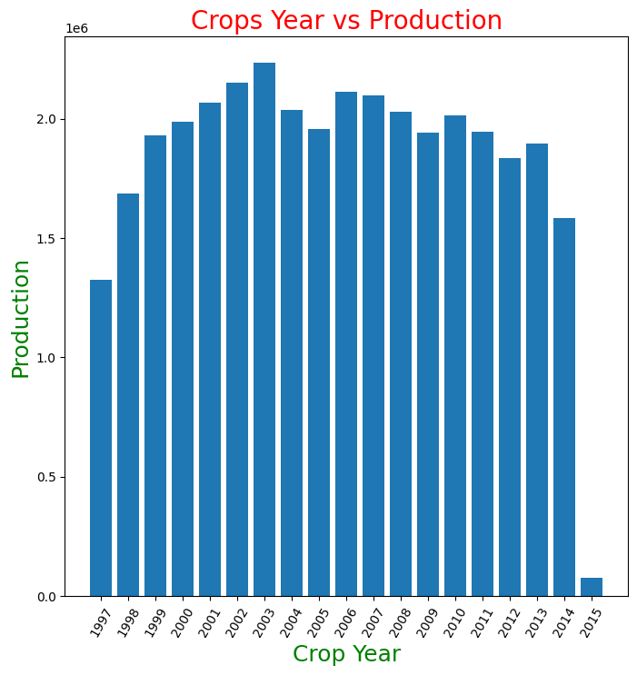

```python
plt.figure(figsize=(8,8))
plt.bar(year_wise_prod.Crop_Year, year_wise_prod.Production, width=0.8)
plt.xticks(year_wise_prod.Crop_Year, rotation = 60)
plt.xlabel("Crop Year", fontsize = 18, color = 'g')
plt.ylabel("Production", fontsize = 18, color = 'g')
plt.title('Crops Year vs Production', fontsize = 20, color = 'r')
```

## 4. Season wise Production

```python
season_wise_prod = df.groupby(by='Season')['Production'].sum().reset_index()
season_wise_prod
```

|  | Season | Production |
| --- | --- | --- |
| 0 | Autumn | 642258.99 |
| 1 | Kharif | 15546068.45 |
| 2 | Rabi | 12403682.45 |
| 3 | Summer | 1926845.40 |
| 4 | Whole Year | 3962242.30 |
| 5 | Winter | 417077.40 |

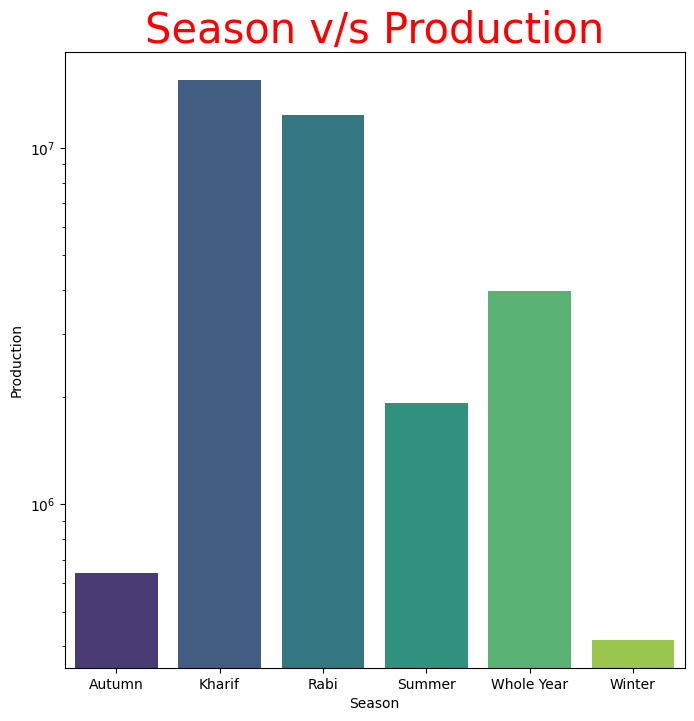

```python
plt.figure(figsize=(8,8))
sns.barplot(x='Season', y='Production',data = season_wise_prod, palette='viridis')
plt.yscale('log')
plt.title('Season v/s Production', fontsize = 30,color = 'r')
plt.show()
```

- Top crop categories which shows high production values are Whole Year(Annual growing plants), Kharif and Rabi crops. - These crop are generally dependent on monsoons.

## 5. Category wise production

[figure not shown]

```python
plt.figure(figsize=(8,8))
plt.tick_params(labelsize=10)
df.groupby("crop_category")["Production"].agg("count").plot.bar()
plt.xlabel("Crop Category", fontsize = 18, color = 'g')
plt.ylabel("Production", fontsize = 18, color = 'g')
plt.title('Crops Category vs Production', fontsize = 20, color = 'r')
plt.show()
```

## 6. Different proportion of crop categories for india

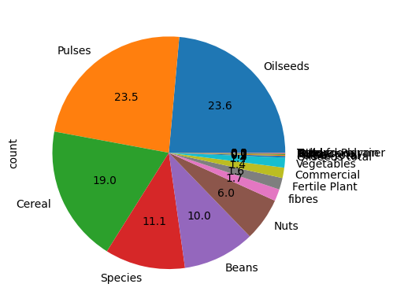

```python
df1=df["crop_category"].value_counts()
df1.plot(radius=1,kind="pie",autopct="%1.1f",pctdistance=0.6)
plt.tick_params(labelsize=10)
```

Top producing crop categories are - Oilseeds - 23.6% - Pulses - 23.5% - Cereals-19.0%